# Bollywood : Indian Cinema

## Narjit Singh

[figure not shown]

# Background

Bollywood is the name for Indian film Industry, similar to Hollywood. The B in Bollywood comes from Bombay (now Mumbai), which is considered to be the heartland for producing Indian movies. Bollywood is massive, it makes around 800 films a year and about 14 million Indian people go to the cinema every day.

Bollywood started in 1899. Just like Hollywood the films were silent until the 1930. One of the biggest thing that separates Bollywood from Hollywood is that Bollywood movies are colorful, crammed with singing, dancing and loads of costumes changes. Most of the movies produced in Bollywood on average would consist of 5-8 songs. Most of the stories in the initial days were based on a formula where a boy meets a girl and how they fall in love with each other and how they would struggle for family approval. There was romance but no kissing!

### Datasets

In order to find all of the information mentioned above, I will be using Bollywood Movie Dataset from Kaggle.com. [(Link)](https://www.kaggle.com/mitesh58/bollywood-movie-dataset/data)

This dataset has three individual datasets in comma separated value (csv), but for the purposes of this tutorial I will be using BollywoodActorRanking.csv, BollywoodMovieDetail.csv

# Load the Data

Let’s load the BollywoodMovieDetail data. We will be using read.csv() function to read the data in R. For example, we are using BollywoodMovieDetail.csv. I can read this particular data by doing read.csv(“BollywoodMovieDetail.csv”). Since, I will be using this data throughout the tutorial, I will assign it to a variable named bollywoodTable. This data contains the name of the movies, their release dates, genre, writers, actors, and hit, flop, directors and information about writers. Since, the data is really big, I will shorten it to just print the first 10 contents of the csv file. This is another way to make sure that contents were read correctly from the csv file. In R, we do that by using Kable. Kable is a very simple table generator. So here, we will generate a simple table that would only print the first ten contents located in the BollywoodMovieDetail.csv file.

```r
bollywoodTable <- read.csv("BollywoodMovieDetail.csv")
kable(bollywoodTable[1:10,])
```

| imdbId | title | releaseYear | releaseDate | genre | writers | actors | directors | sequel | hitFlop |
| --- | --- | --- | --- | --- | --- | --- | --- | --- | --- |
| tt0118578 | Albela | 2001 | 20-Apr-01 | Romance | Honey Irani (screenplay) \| Honey Irani (story) \| Javed Siddiqui (dialogue) | Govinda \| Aishwarya Rai Bachchan \| Jackie Shroff \| Namrata Shirodkar | Deepak Sareen | 0 | 2 |
| tt0169102 | Lagaan: Once Upon a Time in India | 2001 | 8-May-02 | Adventure \| Drama \| Musical | Ashutosh Gowariker (story) \| Ashutosh Gowariker (screenplay) \| Kumar Dave (screenplay) \| Sanjay Dayma (screenplay) \| K.P. Saxena (dialogue) | Aamir Khan \| Gracy Singh \| Rachel Shelley \| Paul Blackthorne | Ashutosh Gowariker | 0 | 6 |
| tt0187279 | Meri Biwi Ka Jawab Nahin | 2004 | 2-Jul-04 | Action \| Comedy | N/A | Akshay Kumar \| Sridevi \| Gulshan Grover \| Laxmikant Berde | Pankaj Parashar \| S.M. Iqbal | 0 | 1 |
| tt0222024 | Hum Tumhare Hain Sanam | 2002 | 24-May-02 | Drama \| Romance | K.S. Adiyaman \| Arun Kumar (assistant dialogue) \| Ashok Mehta (assistant dialogue) \| Reema Rakesh Nath (dialogue) | Shah Rukh Khan \| Madhuri Dixit \| Salman Khan \| Atul Agnihotri | K.S. Adiyaman | 0 | 4 |
| tt0227194 | One 2 Ka 4 | 2001 | 30-Mar-01 | Action \| Comedy \| Drama | Sanjay Chhel \| Raaj Kumar Dahima (screenplay) \| Manoj Lalwani (screenplay) | Shah Rukh Khan \| Juhi Chawla \| Jackie Shroff \| Nirmal Pandey | Shashilal K. Nair | 0 | 1 |
| tt0238936 | Devdas | 2002 | 12-Jul-02 | Musical \| Romance | Saratchandra Chatterjee (based on the novel by) \| Prakash Kapadia (screenplay) \| Sanjay Leela Bhansali (screenplay) \| Prakash Kapadia (dialogue) | Shah Rukh Khan \| Madhuri Dixit \| Aishwarya Rai Bachchan \| Jackie Shroff | Sanjay Leela Bhansali | 0 | 6 |
| tt0247911 | Aap Mujhe Achche Lagne Lage | 2002 | 19-Apr-02 | Action \| Drama \| Romance | Robin Bhatt (story) \| Girish Dhamija (dialogue) \| Sanjeev Duggal (story) | Hrithik Roshan \| Ameesha Patel \| Kiran Kumar \| Mukesh Tiwari | Vikram Bhatt | 0 | 2 |
| tt0248126 | Kabhi Khushi Kabhie Gham… | 2001 | 14-Dec-01 | Drama \| Musical \| Romance | Karan Johar \| Sheena Parikh (screenplay) | Amitabh Bachchan \| Jaya Bhaduri \| Shah Rukh Khan \| Kajol | Karan Johar | 0 | 8 |
| tt0248216 | Na Tum Jaano Na Hum | 2002 | 10-May-02 | Comedy \| Drama \| Musical | Pratibha Acharya (dialogue) \| Arjun Sablok | Saif Ali Khan \| Hrithik Roshan \| Esha Deol \| Alok Nath | Arjun Sablok | 0 | 1 |
| tt0248617 | Yaadein… | 2001 | 27-Jun-01 | Musical \| Drama \| Romance | Subhash Ghai (dialogue) \| Subhash Ghai (screenplay) \| Amrik Gill (dialogue) \| Aatish Kapadia (screenplay) \| Anuradha Tiwari (screenplay) | Jackie Shroff \| Hrithik Roshan \| Kareena Kapoor \| Amrish Puri | Subhash Ghai | 0 | 2 |

From the table above me can see that our data was loaded properly and it is ready to be used for analysis.

# Bollywood Movies Trend

I personally watch a lot of Bollywood movies and I have seen the number of movies released increased every year. Let’s see if we can find this information and see if my intuition is correct. I plan to find this information, by grabbing the releaseYear column from the csv and count how many movies have released since 2000. I will be using a ggplot package to create a graph that would allow us to see visual representation of the data. The ggplot2 package is a powerful package that allow users to create elegant and complex plots. Using the plot, we should be able to find a trend. For example, the increasing line on the graph would indicate a positive trend. While a line decreasing would indicate a negative trend. Let’s find this out by drawing the plot of movies released in Bollywood so far.

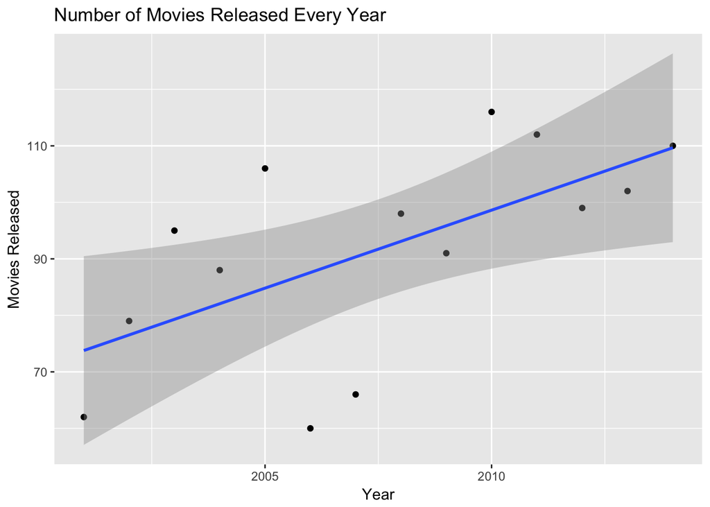

```r
bollywoodTable %>%
            group_by(releaseYear) %>%
            count()%>%
            ggplot(aes(x=releaseYear, y=n))+
            geom_point() +
            geom_smooth(method=lm)+
            labs(title="Number of Movies Released Every Year",x = "Year", y = "Movies Released")
```

## Different Perspective

Although the graph in the previous problem helped us telling about the trend of Bollywood movies, it was somewhat confusing to see how many numbers of movies were released every year and if numbers increased from year to year. Let’s draw a bar graph to see the trend in more details.

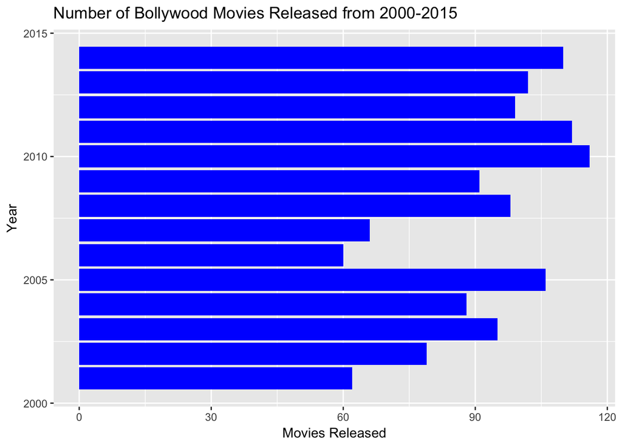

```r
bollywoodTable %>% group_by(releaseYear) %>% count()%>%
                  arrange(desc(n))%>%
                  ungroup()%>%
                  ggplot(aes(x=releaseYear,y =n))+
                  xlab("Year")+
                  ylab("Movies Released")+
                  geom_bar(stat="identity",fill="blue") +
                  ggtitle("Number of Bollywood Movies Released from 2000-2015")+
                  theme_update(plot.title = element_text(hjust = 0.5))+
                  scale_y_continuous()+
                  coord_flip(xlim = NULL, ylim = NULL, expand = TRUE)
```

## Movies Analysis Based on Genre

In previous sections, we found out how many Bollywood movies are released every year. Let’s switch gears and see what type of Bollywood are released every year. In order to find this out, we will use the same dataset but this time focus on the “genre” column. We will use this column to find out what type of movies are released every year.

### Most Favorite Genre

In order to find the most favorite genre in Bollywood, we need to get the column “genre” and it’s data. We will use group_by operating in R. Group_ by() is part of dplyr package and it groups a dataframe based on certain fields. One thing to note is that group_by only groups the values, it doesn not provide any sort of quantitative value. That’s where summarize operation comes into the play. In the code, you can see that we are using a summarize operation. Summarize function will allow us to produce stratified summary statistics and allow us to store the data in a data frame for plotting. We will use counts to count how many genres there are and which one is the most favorite and which one is the least favorite (**we will find that in later sections**).

```r
library(dplyr)
df <- bollywoodTable %>%
  group_by(genre) %>%
  summarize(counts = n()) %>%
  arrange(desc(counts))
y<-kable(df[1:15,])
y
```

| genre | counts |
| --- | --- |
| Drama | 113 |
| Comedy \| Drama \| Romance | 75 |
| Comedy \| Drama | 74 |
| Action \| Crime \| Drama | 70 |
| Comedy | 65 |
| Drama \| Romance | 51 |
| Romance | 46 |
| Comedy \| Romance | 42 |
| Thriller | 37 |
| Comedy \| Crime \| Drama | 28 |
| Action | 26 |
| Drama \| Thriller | 24 |
| Action \| Comedy \| Crime | 23 |
| Crime \| Drama \| Thriller | 21 |
| Drama \| Romance \| Thriller | 19 |

The table above shows the highest number of movies produced based on genre. It can be seen that “Drama” is the number one genre that Bollywood movies are produced in. Second genre is the combination of drama, comedy, and Romance. I used the arrange operation to arrange the number of genres in highest to lowest. Doing this, made it easier for me to find the most favorite genre easily because the highest number would be on the top.

### Least Favorite Genre

Using the same function, let’s find out the least favorite genre in Bollywood.

```r
library(dplyr)
least <- bollywoodTable %>%
  group_by(genre) %>%
  summarize(counts = n()) %>%
  arrange((counts))
y<-kable(least[1:15,])
y
```

| genre | counts |
| --- | --- |
| Action \| Adventure | 1 |
| Action \| Adventure \| Biography | 1 |
| Action \| Adventure \| Fantasy | 1 |
| Action \| Adventure \| Sci-Fi | 1 |
| Action \| Adventure \| Thriller | 1 |
| Action \| Crime \| Fantasy | 1 |
| Action \| Crime \| Musical | 1 |
| Action \| Crime \| Mystery | 1 |
| Action \| Drama \| Sport | 1 |
| Action \| Fantasy \| Horror | 1 |
| Action \| Musical \| Drama | 1 |
| Action \| Musical \| Mystery | 1 |
| Action \| Sci-Fi | 1 |
| Action \| Thriller \| Crime | 1 |
| Action \| Thriller \| Drama | 1 |

### Genre Graphs

Let’s plot all the results that we found about movies based on their genre.

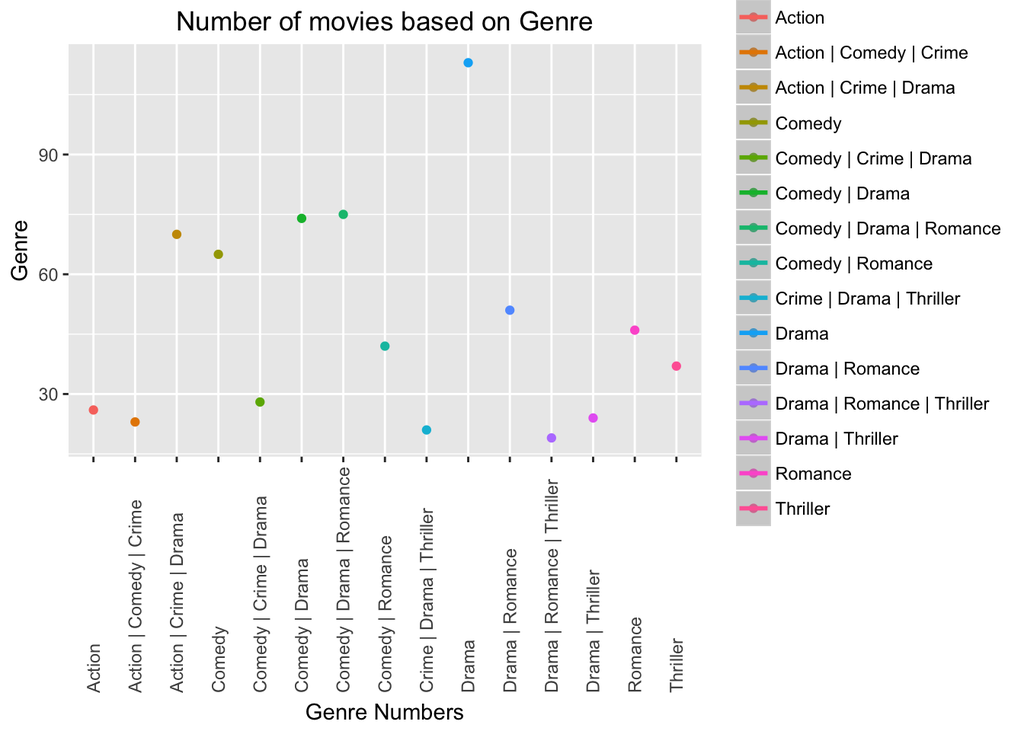

```r
x<-head(df, n=15)

ggplot(x, aes(genre, counts, colour = genre)) + geom_point()+
 xlab("Genre Numbers") +
 ylab("Genre") +
 ggtitle("Number of movies based on Genre")+
 geom_smooth(method = 'lm')+
 theme(axis.text.x = element_text(angle = 90, vjust=0.5, hjust=0))
```

From the above plot, we can see the top 15 genres in Bollywood. We can also see that most of the genres are closed together, whereas “drama” is in totally different location. This is an great indication of how Bollywood loves producing drama movies. This is also an indication of how people love drama movies. Bollywood wouldn’t be producing these movies at such a high rate, they people didn’t love them.

# Biggest Hit Bollywood Movies

The industry runs on how much money a movie makes, which is another way of saying how many people appreciated the movie. The dataset contains a column, “hitFlop”, I will be using this column to find which movies were hit and which flopped. The hit and flop column is populated based on rating from various sources like IMDB rating, and how much money they made. Here is the rating scale define in the csv file:

**Rating Scale:**

**1** Ridiculous (Burn)

**2** Awful (Nobody can you cant borrow it))

**3** Bad (No but you can borrow it)

**4** ehh (No desire to watch again might with someone)

**5** Average (Probably not)

**6** Good (Maybe)

**7** Good + (Probably)

**8** Very Good (Again)

**9** Excellent (Again and Again)

**10** Amazing (Indefinitely)

### Plot 1: Rating higher than 4

Since, the rating of 5 describes the movie as average, we will start from that. Let’s find out all the movies with a rating of 5 and above. Since we want to find out all the movies with a rating of five or more, we will use the filter function to filter out the movies we want. In the code, I am using filter function to find all the movies with a hitFlop rating of above 5. After filtering out, I am just creating a bar graph, that would allow me to see visual representation of the results.

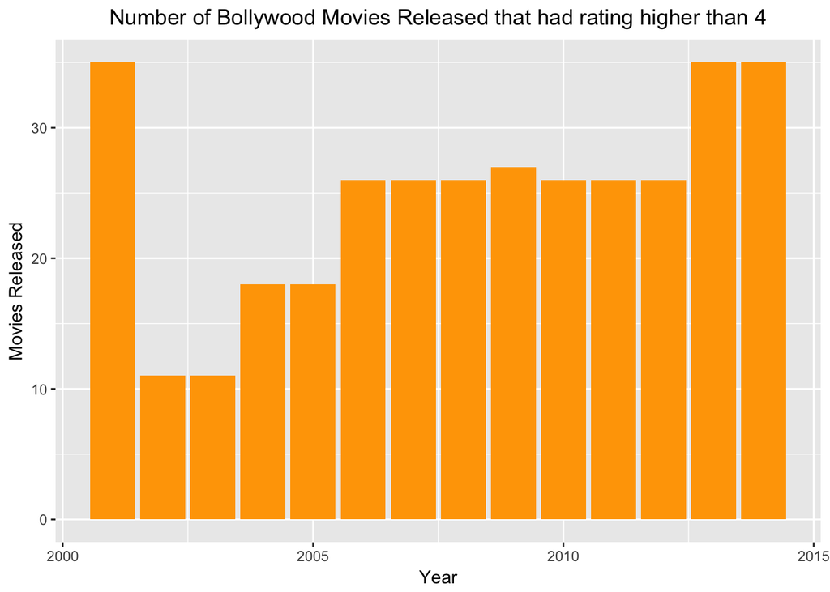

```r
bollywoodTable %>% group_by(releaseYear,hitFlop) %>% count()%>%
                  arrange(desc(n))%>%
                  filter(hitFlop > 4)%>%
                  ggplot(aes(x=releaseYear,y = hitFlop))+
                  xlab("Year")+
                  ylab("Movies Released")+
                  geom_bar(stat="identity",fill="orange") +
                  ggtitle("Number of Bollywood Movies Released that had rating higher than 4")
```

### Plot 2: Biggest Hits (rating higher than 8)

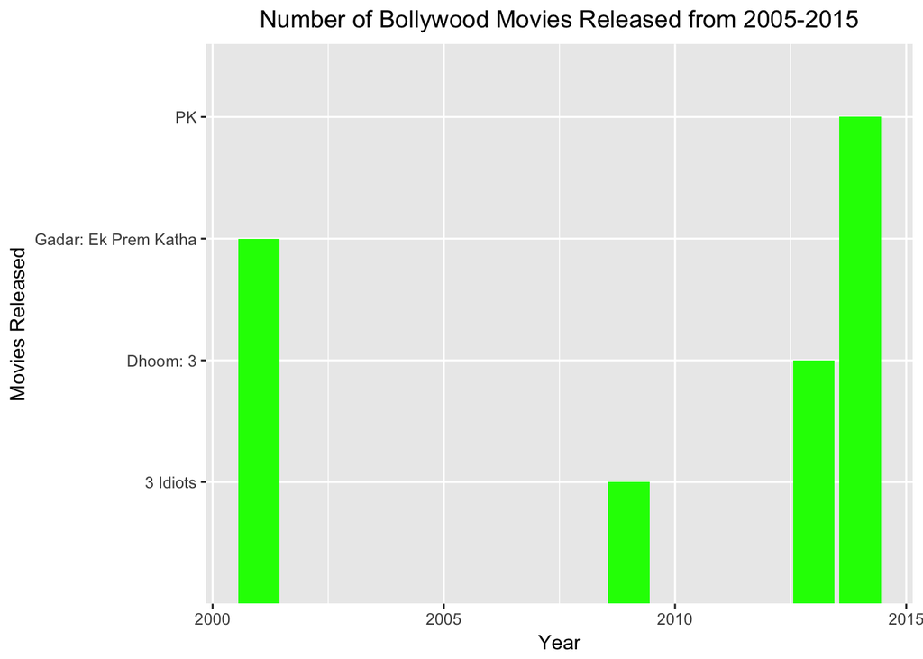

```r
bollywoodTable %>% group_by(releaseYear,title,hitFlop) %>% count()%>%
                  arrange(desc(n))%>%
                  filter(hitFlop > 8)%>%
                  ggplot(aes(x=releaseYear,y = title))+
                  xlab("Year")+
                  ylab("Movies Released")+
                  geom_bar(stat="identity",fill="green") +
                  ggtitle("Number of Bollywood Movies Released from 2005-2015")
```

### Table 1: Movies based on Rating

Let’s find out how many movies are released based on the rating. This will tell us how many movies Bollywood produces are success and how many are flops.

```r
library(dplyr)
rating <- bollywoodTable %>%
  group_by(hitFlop) %>%
  summarize(counts = n())
movies_list <- head(rating, 9)
y<-kable(rating)
y
```

| hitFlop | counts |
| --- | --- |
| 1 | 729 |
| 2 | 257 |
| 3 | 55 |
| 4 | 68 |
| 5 | 58 |
| 6 | 64 |
| 7 | 29 |
| 8 | 20 |
| 9 | 4 |

This is really surprising. The rating of number 1 (worst rating) outperforms the number of high rated movies. This means Bollywood industry is producing more flop movies than hit movies. It can be seen in the table that 729 received the lowest rating possible for movie.

### Visual Representation of Table 1

Let’s plot table one and see how it looks like.

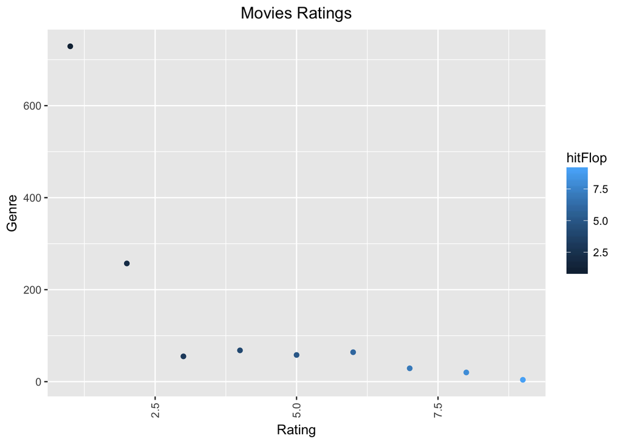

```r
ggplot(movies_list, aes(hitFlop, counts, colour = hitFlop)) + geom_point()+
  xlab("Rating") +
 ylab("Genre") +
 ggtitle("Movies Ratings")+
 theme(axis.text.x = element_text(angle = 90, vjust=0.5, hjust=0))
```

# Actors

The dataset we have used in the previous section does not provide any information about actors, how successful they are as an actor, and what are their ratings. As I talked earlier, Bollywood Movie Dataset from Kaggle.com had three datasets. So far we have used, “BollywoodMovieDetail.csv”. Let’s use the dataset, “BollywoodActorRanking.csv” to analyze all the actors of Bollywood.

```r
actor_table <- read.csv("BollywoodActorRanking.csv")
kable(actor_table[1:10,])
```

| actorId | actorName | movieCount | ratingSum | normalizedMovieRank | googleHits | normalizedGoogleRank | normalizedRating |
| --- | --- | --- | --- | --- | --- | --- | --- |
| 373 | Aamir Khan | 11 | 1170 | 9.448619842529297 | 2460000 | 7.342830181121826 | 10.00000 |
| 374 | Shah Rukh Khan | 23 | 2000 | 7.5500898361206055 | 2670000 | 7.884580135345459 | 9.22674 |
| 375 | Salman Khan | 36 | 2340 | 5.402170181274414 | 3490000 | 10 | 9.20821 |
| 376 | Katrina Kaif | 17 | 1640 | 8.480819702148438 | 2120000 | 6.465700149536133 | 8.94852 |
| 377 | Deepika Padukone | 16 | 1080 | 5.646739959716797 | 3000000 | 8.735910415649414 | 8.62716 |
| 378 | Hrithik Roshan | 16 | 1120 | 5.891300201416016 | 2650000 | 7.832980155944824 | 8.25194 |
| 379 | Priyanka Chopra | 36 | 1990 | 4.451089859008789 | 3130000 | 9.071279525756836 | 8.13686 |
| 380 | Kareena Kapoor | 37 | 2200 | 4.860159873962402 | 2940000 | 8.581119537353516 | 8.09065 |
| 381 | Ranbir Kapoor | 11 | 890 | 6.958499908447266 | 1860000 | 5.794960021972656 | 7.69864 |
| 382 | Kajol | 6 | 450 | 6.380430221557617 | 1780000 | 5.588580131530762 | 7.25156 |

The table above gives a list of all the actors with their rating, movie count and google hits. We want to find out who is the biggest actor in the industry, so we need to arrange the table based on rating sum of the actor.

### Biggest Bollywood Starts

```r
library(dplyr)
actor_ratings <- actor_table %>%
  group_by(ratingSum) %>%
  arrange(desc(ratingSum))
y<-kable(actor_ratings[1:15,])
y
```

| actorId | actorName | movieCount | ratingSum | normalizedMovieRank | googleHits | normalizedGoogleRank | normalizedRating |
| --- | --- | --- | --- | --- | --- | --- | --- |
| 391 | Akshay Kumar | 54 | 2950 | 4.3876800537109375 | 1960000 | 6.0529398918151855 | 6.38048 |
| 375 | Salman Khan | 36 | 2340 | 5.402170181274414 | 3490000 | 10 | 9.20821 |
| 387 | Ajay Devgn | 49 | 2320 | 3.6752400398254395 | 2570000 | 7.6265997886657715 | 6.87132 |
| 380 | Kareena Kapoor | 37 | 2200 | 4.860159873962402 | 2940000 | 8.581119537353516 | 8.09065 |
| 384 | Amitabh Bachchan | 48 | 2140 | 3.4048900604248047 | 2770000 | 8.142560005187988 | 7.01130 |
| 374 | Shah Rukh Khan | 23 | 2000 | 7.5500898361206055 | 2670000 | 7.884580135345459 | 9.22674 |
| 379 | Priyanka Chopra | 36 | 1990 | 4.451089859008789 | 3130000 | 9.071279525756836 | 8.13686 |
| 404 | Abhishek Bachchan | 34 | 1770 | 4.136189937591553 | 1260000 | 4.247089862823486 | 5.20794 |
| 409 | Sanjay Dutt | 43 | 1740 | 3.0020198822021484 | 1560000 | 5.021029949188232 | 5.00264 |
| 436 | Paresh Rawal | 30 | 1660 | 4.456520080566406 | 176000 | 1.4506100416183472 | 3.79672 |
| 376 | Katrina Kaif | 17 | 1640 | 8.480819702148438 | 2120000 | 6.465700149536133 | 8.94852 |
| 415 | Bipasha Basu | 34 | 1570 | 3.5607399940490723 | 1050000 | 3.7053399085998535 | 4.57122 |
| 456 | Sunil Shetty | 42 | 1530 | 2.607140064239502 | 560000 | 2.4412500858306885 | 3.30729 |
| 432 | Rani Mukerji | 27 | 1410 | 4.152170181274414 | 386000 | 1.99235999584198 | 3.93202 |
| 414 | Emraan Hashmi | 26 | 1400 | 4.311039924621582 | 861000 | 3.2177600860595703 | 4.72095 |

The table above arranges the actors based on their rating sum. Based on this, Akshay Kumar turns out to be the biggest star in Bollywood. Using the group_by and arrange functions (described previously) I was able to make the list sorted based on the rating.

### Plot 1: Top Five stars in Bollywood

let’s find out the top five stars in Bollywood.

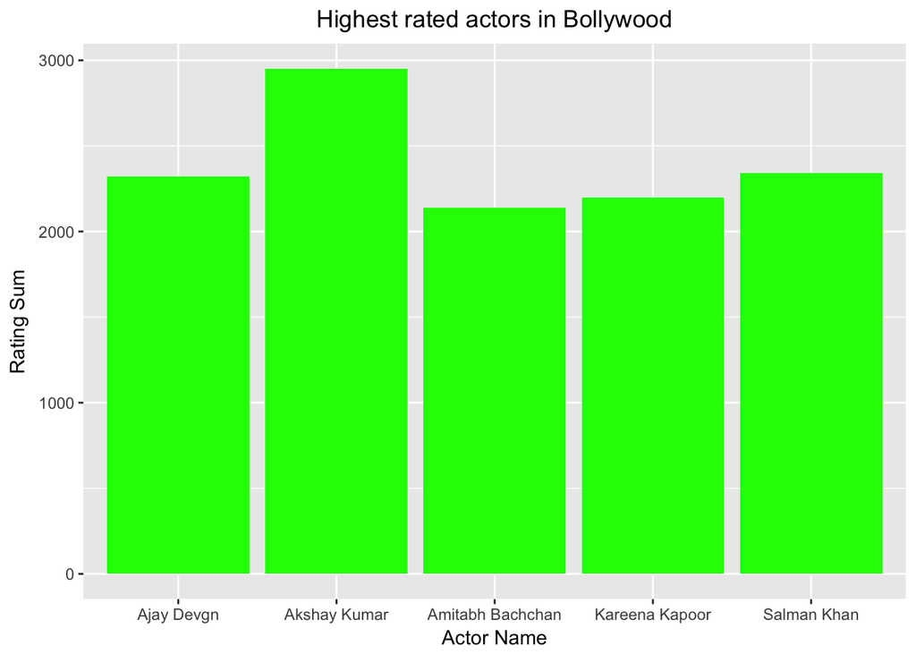

```r
actor_ratings %>% group_by(ratingSum,actorName) %>% count()%>%
                  arrange(desc(n))%>%
                  filter(ratingSum > 2000)%>%
                  ggplot(aes(x=actorName,y = ratingSum))+
                  xlab("Actor Name")+
                  ylab("Rating Sum")+
                  geom_bar(stat="identity",fill="green") +
                  ggtitle("Highest rated actors in Bollywood")
```

It can be seen that Akshay Kumar is the number one star in bollywood, then comes Salman Khan, Ajay Devgan, then Kareena Kapoor (actress) , and Amitabh Bachchan.

Find more information about these actors click on the links below:

1. [Akshay Kumar](https://en.wikipedia.org/wiki/Akshay_Kumar)
2. [Salman Khan](https://en.wikipedia.org/wiki/Salman_Khan)
3. [Ajay Devgan](https://en.wikipedia.org/wiki/Ajay_Devgn)
4. [Kareena Kapoor](https://en.wikipedia.org/wiki/Kareena_Kapoor)
5. [Amitabh Bachchan](https://en.wikipedia.org/wiki/Amitabh_Bachchan)

### Actor: Highest Number of Movies

Let’s find out actors with highest number of movies.

```r
moviecount <- actor_table %>%
  group_by(movieCount) %>%
  arrange(desc(movieCount))
y<-kable(moviecount[1:15,])
y
```

| actorId | actorName | movieCount | ratingSum | normalizedMovieRank | googleHits | normalizedGoogleRank | normalizedRating |
| --- | --- | --- | --- | --- | --- | --- | --- |
| 391 | Akshay Kumar | 54 | 2950 | 4.3876800537109375 | 1960000 | 6.0529398918151855 | 6.38048 |
| 387 | Ajay Devgn | 49 | 2320 | 3.6752400398254395 | 2570000 | 7.6265997886657715 | 6.87132 |
| 384 | Amitabh Bachchan | 48 | 2140 | 3.4048900604248047 | 2770000 | 8.142560005187988 | 7.01130 |
| 409 | Sanjay Dutt | 43 | 1740 | 3.0020198822021484 | 1560000 | 5.021029949188232 | 5.00264 |
| 456 | Sunil Shetty | 42 | 1530 | 2.607140064239502 | 560000 | 2.4412500858306885 | 3.30729 |
| 380 | Kareena Kapoor | 37 | 2200 | 4.860159873962402 | 2940000 | 8.581119537353516 | 8.09065 |
| 375 | Salman Khan | 36 | 2340 | 5.402170181274414 | 3490000 | 10 | 9.20821 |
| 379 | Priyanka Chopra | 36 | 1990 | 4.451089859008789 | 3130000 | 9.071279525756836 | 8.13686 |
| 450 | Anupam Kher | 36 | 1310 | 2.603260040283203 | 657000 | 2.6914799213409424 | 3.44770 |
| 404 | Abhishek Bachchan | 34 | 1770 | 4.136189937591553 | 1260000 | 4.247089862823486 | 5.20794 |
| 415 | Bipasha Basu | 34 | 1570 | 3.5607399940490723 | 1050000 | 3.7053399085998535 | 4.57122 |
| 551 | Gulshan Grover | 33 | 950 | 1.8596800565719604 | 101000 | 1.2571300268173218 | 2.20643 |
| 425 | Om Puri | 32 | 1100 | 2.40625 | 1230000 | 4.1697001457214355 | 4.17789 |
| 436 | Paresh Rawal | 30 | 1660 | 4.456520080566406 | 176000 | 1.4506100416183472 | 3.79672 |
| 383 | John Abraham | 27 | 1370 | 4.00724983215332 | 2610000 | 7.729790210723877 | 7.11935 |

From the table above we can see that Akshay Kumar holds the title of highest number of movies in Bollywood and these results seem to match up with his ranking. If you check his page ([Akshay Kumar](https://en.wikipedia.org/wiki/Akshay_Kumar)), you will find out that he completes about 3-4 movies a year and most of them are hit movies, which is extraordinary.

### Plot: Actors with Number of Movies

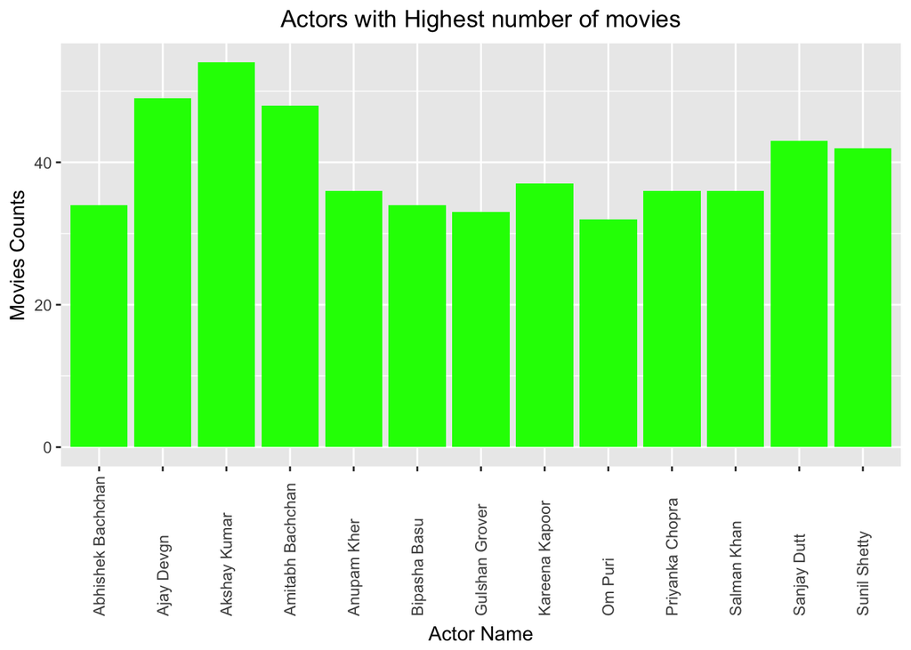

```r
moviecount %>% group_by(movieCount,actorName) %>% count()%>%
                  arrange(desc(n))%>%
                  filter(movieCount > 30)%>%
                  ggplot(aes(x=actorName,y = movieCount))+
                  xlab("Actor Name")+
                  ylab("Movies Counts")+
                  geom_bar(stat="identity",fill="green") +
                  ggtitle("Actors with Highest number of movies")+
 theme_update(plot.title = element_text(hjust = 0.5))+
 scale_y_continuous()+
 theme(axis.text.x = element_text(angle = 90, vjust=0.5, hjust=0))
```

# More Information

If you are interested in learning more about Bollywood, here are some resources:

1. [What is Bollywood?](https://en.wikipedia.org/wiki/Bollywood)
2. [Bollywood News](http://www.bollywoodnews.org/)
3. [Box Office Collection and Ratings](https://boxofficeindia.com/)
4. [Biggest Bollywood Movies of All Time](https://en.wikipedia.org/wiki/List_of_highest-grossing_Indian_films)

# Sources

1. [Dataset](https://www.kaggle.com/mitesh58/bollywood-movie-dataset/data)
2. [Intro Image Used](https://www.indiatvnews.com/entertainment/bollywood/bollywood-lifeline-for-pakistani-film-industry-25502.html)